# 第13章 数据聚类与分群分析

- 非监督式学习的数据集只有特征变量, 而没有目标变量, 我们需要对已有数据进行建模, 根据性质进行分组, 其典型案例就是聚类分析问题
- 这章讲解聚类分析的两种常见算法--KMeans和DBSCAN算法

## 13.1 KMeans算法

### 13.1.1 KMeans算法的基本原理

- KMeans算法名称中的K代表类别数量, Means代表每个类别内样本的均值, 所以KMeans算法又称为K-均值算法
- KMeans算法以距离作为样本间相似度的度量标准, 将距离相近的样本分配至同一个类别, 样本间距离的计算方式可以是**欧式距离、曼哈顿距离、余弦相似度**等, KMeans算法**通常采用欧式距离**来度量各样本间的距离
- KMeans算法的核心思想是对每个样本点计算到各个中心点的距离, 并将该样本点分配给距离最近的中心点代表的类别, 一次迭代完成后, 根据聚类结果更新每个类别的中心点, 然后重复之前的操作再次迭代, 直到前后两次分类结果没有差别

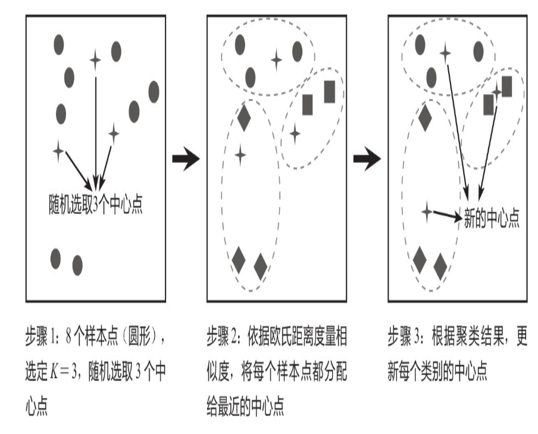

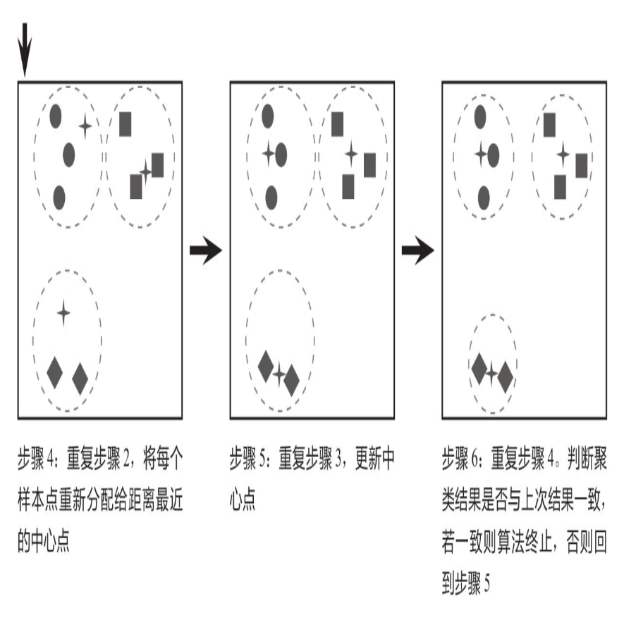

### 13.1.2 KMeans算法的代码实现

```python
import warnings
warnings.filterwarnings('ignore')
```

```python
import numpy as np
data = np.array([[3, 2], [4, 1], [3, 6], [4, 7], [3, 9], [6, 8], [6, 6], [7, 7]])
```

```python
data
```

```
array([[3, 2],
       [4, 1],
       [3, 6],
       [4, 7],
       [3, 9],
       [6, 8],
       [6, 6],
       [7, 7]])
```

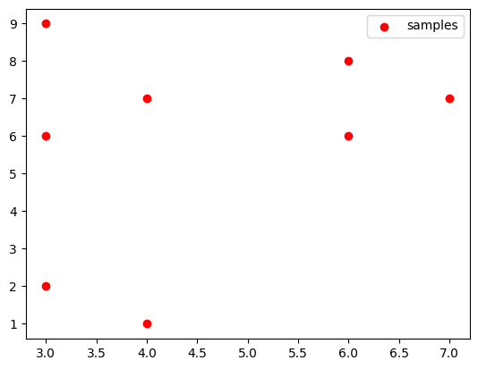

```python
import matplotlib.pyplot as plt
plt.scatter(data[:, 0], data[:, 1], c="red", marker='o', label='samples')  # 以红色圆圈样式绘制散点图并加上标签
plt.legend()  # 设置图例，图例内容为上面设置的label参数
plt.show()
```

```python
from sklearn.cluster import KMeans
kms = KMeans(n_clusters=2)
kms.fit(data)
```

```
KMeans(n_clusters=2)
```

```python
# 获取结果
label = kms.labels_
print(label)
```

```
[0 0 1 1 1 1 1 1]
```

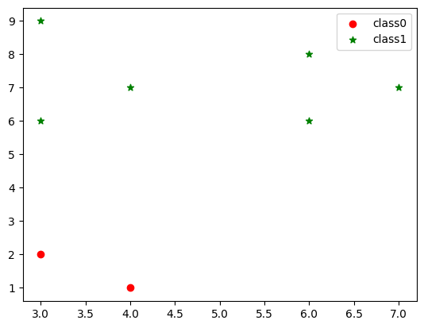

```python
# 结果可视化

plt.scatter(data[label == 0][:, 0], data[label == 0][:, 1], c="red", marker='o', label='class0')  # 以红色圆圈样式绘制散点图并加上标签
plt.scatter(data[label == 1][:, 0], data[label == 1][:, 1], c="green", marker='*', label='class1')  # 以绿色星星样式绘制散点图并加上标签
plt.legend()  # 设置图例
```

```python
# 聚成3类

kms_3 = KMeans(n_clusters=3)
kms_3.fit(data)
label_3 = kms_3.labels_
print(label_3)
```

```
[1 1 0 0 0 2 2 2]
```

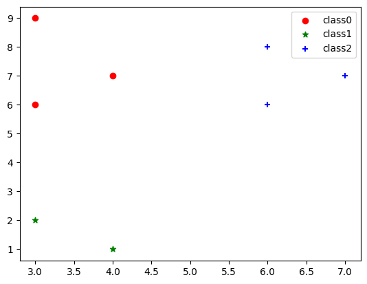

```python
plt.scatter(data[label_3 == 0][:, 0], data[label_3 == 0][:, 1], c="red", marker='o', label='class0')  # 以红色圆圈样式绘制散点图并加上标签
plt.scatter(data[label_3 == 1][:, 0], data[label_3 == 1][:, 1], c="green", marker='*', label='class1')  # 以绿色星星样式绘制散点图并加上标签
plt.scatter(data[label_3 == 2][:, 0], data[label_3 == 2][:, 1], c="blue", marker='+', label='class2')  # 以蓝色加号样式绘制散点图并加上标签
plt.legend()  # 设置图例
```

### 13.1.3 案例实战: 银行客户分群模型

- 银行拥有海量的客户，对于不同的客户，银行需要采取不同的营销工作策略

  例如，对于收入高且风险承受能力强的客户，可以重点挖掘业务机会，如向其推销一些收益率高但周期相对较长的理财产品；而对于收入低且风险承受能力较弱的客户，则需要采取其他策略

  因此，银行通常需要将客户进行分群处理，以便有的放矢地开展营销工作

```python
import pandas as pd
data = pd.read_excel('客户信息.xlsx')
data.head()
```

|  | 年龄(岁) | 收入(万元) |
| --- | --- | --- |
| 0 | 50 | 66 |
| 1 | 44 | 51 |
| 2 | 30 | 56 |
| 3 | 46 | 50 |
| 4 | 32 | 50 |

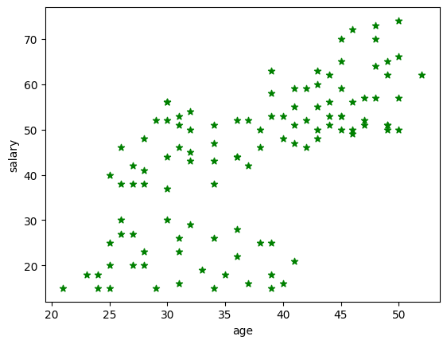

```python
import matplotlib.pyplot as plt
plt.scatter(data.iloc[:, 0], data.iloc[:, 1], c="green", marker='*')  # 以绿色星星样式绘制散点图
plt.xlabel('age')  # 添加x轴名称
plt.ylabel('salary')  # 添加y轴名称
plt.show()
```

```python
from sklearn.cluster import KMeans
kms = KMeans(n_clusters=3, random_state=123)
kms.fit(data)
label = kms.labels_
label = kms.fit_predict(data)
```

```python
print(label)
```

```
[1 1 2 1 2 2 1 2 2 1 1 1 1 2 1 1 1 2 1 1 1 2 2 1 1 1 1 2 2 1 2 1 2 2 2 0 2
 1 2 0 1 1 2 1 2 1 2 1 1 2 2 0 1 2 1 1 1 1 2 1 2 2 2 2 0 0 0 0 0 0 0 0 0 0
 0 0 0 0 0 0 0 0 0 0 0 0 0 1 1 1 1 1 1 1 1 2 2 2 2 1 1 1 2 1 2 0 0 0 0 0 0
 2]
```

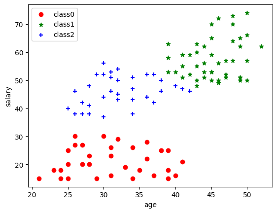

```python
plt.scatter(data[label == 0].iloc[:, 0], data[label == 0].iloc[:, 1], c="red", marker='o', label='class0')  # 以红色圆圈样式绘制散点图并加上标签
plt.scatter(data[label == 1].iloc[:, 0], data[label == 1].iloc[:, 1], c="green", marker='*', label='class1')  # 以绿色星星样式绘制散点图并加上标签
plt.scatter(data[label == 2].iloc[:, 0], data[label == 2].iloc[:, 1], c="blue", marker='+', label='class2')  # 以蓝色加号样式绘制散点图并加上标签
plt.xlabel('age')  # 添加x轴名称
plt.ylabel('salary')  # 添加y轴名称
plt.legend()  # 设置图例
```

```python
print(data[label == 0].iloc[:, 1].mean())  # 看下分类为标签0的人的收入均值，iloc[:, 1]为data表格的第二列，也即“收入”列
print(data[label == 1].iloc[:, 1].mean())
print(data[label == 2].iloc[:, 1].mean())
```

```
21.125
57.55555555555556
46.285714285714285
```

## 13.2 DBSCAN算法

- DBSCAN（Density-Based Spatial Clustering ofApplications with Noise）是一种**以密度为基础**的空间聚类算法，可以用密度的概念剔除不属于任一类别的噪声点

  该算法将簇定义为密度相连的点的最大集合，将具有足够密度的区域划分为簇，并可以发现任意形状的簇

### 13.2.1 DBSCAN算法的基本原理

- 一个案例

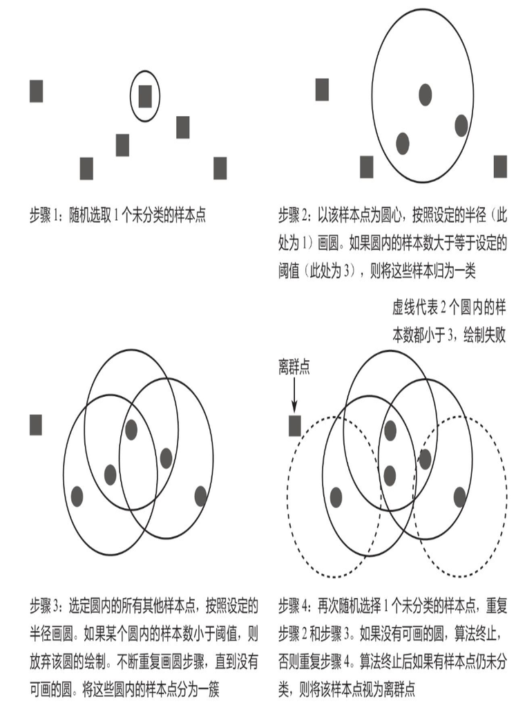

- 一个[可视化网站](https://www.naftaliharris.com/blog/visualizing-dbscan-clustering/)

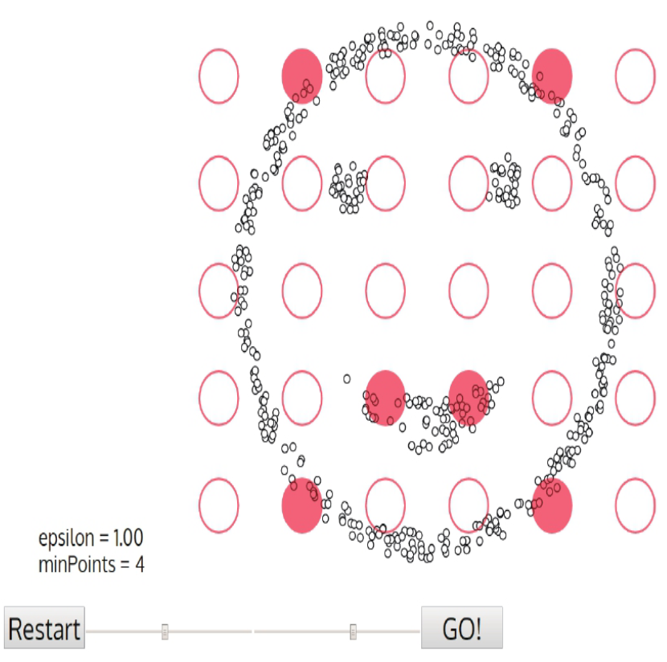

  打开网站后选择 "Smiley Face" 类的数据, 参数 "epsilon" 代表画圆半径, 参数 "minPoints" 代表圆内最小样本数, 可自主调节, 画圆半径越小、圆内最小样本数越大, 对于簇的产生越严格、密度要求越高、离群点越多

  点击 "Go!" 按钮开始演示DBSCAN算法的聚类过程

这里放一个演示

[figure not shown]

### 13.2.2 DBSCAN算法的代码实现及与KMeans的对比

```python
import pandas as pd
data = pd.read_excel('演示数据.xlsx')
data.head()
```

|  | x | y |
| --- | --- | --- |
| 0 | 10.44 | 5.74 |
| 1 | 11.55 | 6.16 |
| 2 | 11.36 | 5.10 |
| 3 | 10.62 | 6.12 |
| 4 | 11.20 | 5.39 |

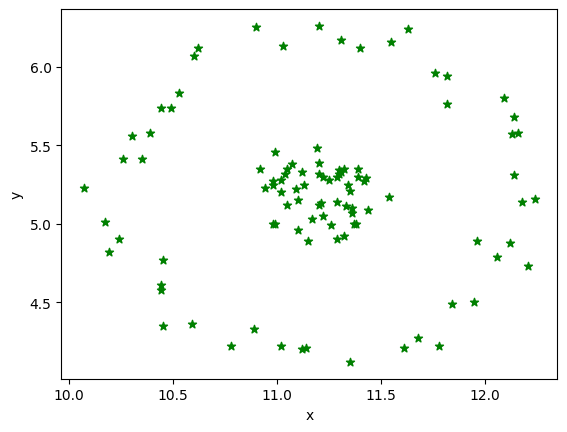

```python
import matplotlib.pyplot as plt
plt.scatter(data.iloc[:, 0], data.iloc[:, 1], c="green", marker='*')  # 以绿色星星样式绘制散点图
plt.xlabel('x')  # 添加x轴名称
plt.ylabel('y')  # 添加y轴名称
plt.show()
```

#### DBSCAN

```python
from sklearn.cluster import DBSCAN
dbs = DBSCAN()
dbs.fit(data)
label_dbs = dbs.labels_
```

```python
print(label_dbs)
```

```
[0 0 1 0 1 0 1 1 0 0 0 0 1 0 0 0 0 0 0 1 1 0 1 1 1 1 0 1 1 0 1 1 0 1 1 1 0
 1 0 0 0 1 0 1 0 1 0 0 1 0 1 0 0 1 0 0 0 1 1 1 0 1 1 0 0 0 0 0 1 1 0 0 0 1
 1 1 1 1 1 0 1 0 0 1 0 0 1 0 1 1 1 1 0 1 1 1 0 1 1 0]
```

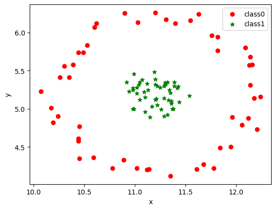

```python
plt.scatter(data[label_dbs == 0].iloc[:, 0], data[label_dbs == 0].iloc[:, 1], c="red", marker='o', label='class0')  # 以红色圆圈样式绘制散点图并加上标签
plt.scatter(data[label_dbs == 1].iloc[:, 0], data[label_dbs == 1].iloc[:, 1], c="green", marker='*', label='class1')  # 以绿色星星样式绘制散点图并加上标签
plt.xlabel('x')  # 添加x轴名称
plt.ylabel('y')  # 添加y轴名称
plt.legend()  # 设置图例
```

#### KMeans

```python
from sklearn.cluster import KMeans
KMs = KMeans(n_clusters=2)
KMs.fit(data)
label_kms = KMs.labels_
```

```python
# KMs # 这样可以查看模型参数，这里没有设置random_state参数，所以可能每次跑出来的结果略有不同（因为每次起始点选的地方不同）
```

```python
print(label_kms)
```

```
[1 1 0 1 1 1 0 0 0 0 0 0 0 1 1 0 1 1 0 1 0 0 1 1 1 1 0 1 1 1 1 1 1 1 1 1 1
 0 0 0 0 1 1 1 1 0 1 1 0 1 1 0 1 1 1 0 1 0 0 1 1 1 1 1 0 0 0 1 0 1 0 0 1 0
 1 0 0 1 1 1 0 0 0 1 0 0 0 0 1 0 1 0 1 0 1 1 0 1 0 0]
```

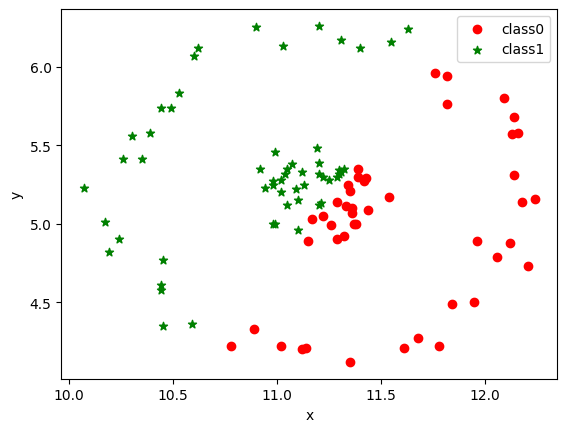

```python
plt.scatter(data[label_kms == 0].iloc[:, 0], data[label_kms == 0].iloc[:, 1], c="red", marker='o', label='class0')  # 以红色圆圈样式绘制散点图并加上标签
plt.scatter(data[label_kms == 1].iloc[:, 0], data[label_kms == 1].iloc[:, 1], c="green", marker='*', label='class1')  # 以绿色星星样式绘制散点图并加上标签
plt.xlabel('x')  # 添加x轴名称
plt.ylabel('y')  # 添加y轴名称
plt.legend()  # 设置图例
```

可以看到，对于形状类似同心圆的数据，KMeans算法聚类效果较差，只能机械地将数据分为左右两部分，而无法以外圆内圆的方式进行区分

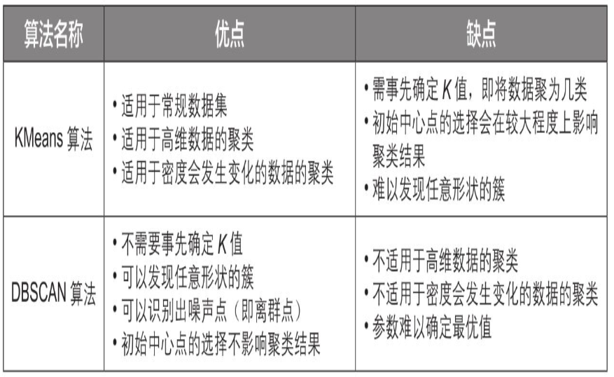

## 13.3 案例实战: 新闻聚类分群模型

### 13.3.1 案例背景

- 新闻种类繁复多样，可以分为财经、体育、科技、娱乐等题材

  在本案例中，根据10个关键词从百度新闻爬取了962条新闻（具体方法可以参考本章最后的第2个“补充知识点”），且每个关键词对应的新闻条数相近，现在需要通过Python编程对每条新闻划分类别，匹配到正确的版面，这实际上就是在对新闻进行聚类分群

### 13.3.2 文本数据的读取与处理

- 在进行新闻聚类分群之前，需要读取新闻数据

  新闻数据是文本类型的，并不能直接用于模型训练，所以读取数据之后还需要将文本类型的数据处理成数值类型的数据

```python
import pandas as pd
df = pd.read_excel('新闻.xlsx')
df.head()
```

|  | 关键词 | 标题 | 网址 | 来源 | 时间 |
| --- | --- | --- | --- | --- | --- |
| 0 | 华能信托 | 信托公司2019年上半年经营业绩概览 | http://www.financialnews.com.cn/jrsb_m/xt/zx/2... | 中国金融新闻网 | 2019年07月23日 00:00 |
| 1 | 华能信托 | 首单信托型企业ABS获批 | http://www.jjckb.cn/2018-10/23/c_137552198.htm | 经济参考网 | 2018年10月23日 12:21 |
| 2 | 华能信托 | 华能贵诚信托孙磊:金融科技助力打造开放信托生态 | https://baijiahao.baidu.com/s?id=1639276579449... | 同花顺财经 | 2019年07月17日 10:49 |
| 3 | 华能信托 | 华能贵诚信托孙磊:金融科技已经成为信托行业重要的基础设施 | https://finance.qq.com/a/20190716/007898.htm | 腾讯财经 | 2019年07月16日 18:53 |
| 4 | 华能信托 | 格力电器股权转让意向方闭门开会 华能信托赫然在列 | https://finance.sina.com.cn/trust/roll/2019-05... | 新浪 | 2019年05月22日 22:53 |

- 在前面的章节中出现的数据可以分为连续型（如0～100的连续值）和离散型（如样本的类别0和1）两类，但还有一类数据是文本数据，如本节中的新闻标题文本

  这种文本类型的数据需要转换为数值类型的数据才能在Python中处理

  这项工作需要用到两个核心技术——**中文分词**和**文本向量化**
  - **中文分词**:

    中文分词就是将一句话拆分成一些词语，例如，“我爱北京天安门”就可以拆分成“我”“爱”“北京”“天安门”

    中文分词后就可以进行文本向量化，搭建词频矩阵，从而将文本转换为数字

    在Python中有专门进行中文分词的jieba库，这里主要讲解jieba库的核心知识点，jieba库的更多扩展知识见本章最后的第1个“补充知识点”

#### 2 中文分词

```python
# 如果没有安装jieba库，可以将下面代码取消注释后运行，即可安装jieba库
# !pip install jieba
```

```python
import warnings

warnings.filterwarnings('ignore')
```

```python
# 中文分词演示
import jieba
word = jieba.cut('我爱北京天安门')
for i in word:
    print(i)
```

[output not shown]

```
我
爱
北京
天安门
```

```python
# 第一条新闻标题
df.iloc[0]['标题']
```

```
'信托公司2019年上半年经营业绩概览'
```

```python
# 第一条新闻标题中文分词
import jieba
word = jieba.cut(df.iloc[0]['标题'])
result = ' '.join(word)
print(result)
```

```
信托公司 2019 年 上半年 经营 业绩 概览
```

```python
# 通过for循环遍历来进行所有标题的分词
import jieba
words = []
for i, row in df.iterrows():
    word = jieba.cut(row['标题']) # 这里的word是一个generator
    result = ' '.join(word) # 单引号里的是分隔符, 这里将word变为一个str
    words.append(result)
```

```python
# generator

# 生成器表达式
gen_expr = (i * 2 for i in range(5))

print(type(gen_expr))

# 遍历生成器
for num in gen_expr:
    print(num)
```

```
<class 'generator'>
0
2
4
6
8
```

```python
words[0:3]  # 展示前三条新闻的分词结果
```

```
['信托公司 2019 年 上半年 经营 业绩 概览',
 '首单 信托 型 企业 ABS 获批',
 '华能 贵 诚信 托孙磊 : 金融 科技 助力 打造 开放 信托 生态']
```

```python
# 熟悉了上面的过程后，可以把代码合并写成如下形式
import jieba
words = []
for i, row in df.iterrows():
    words.append(' '.join(jieba.cut(row['标题'])))
```

```python
print(len(words))
```

```
962
```

```python
words[0:3]  # 同样展示前三条新闻的分词结果
```

```
['信托公司 2019 年 上半年 经营 业绩 概览',
 '首单 信托 型 企业 ABS 获批',
 '华能 贵 诚信 托孙磊 : 金融 科技 助力 打造 开放 信托 生态']
```

##### 补充知识点：遍历DataFrame表格的函数 - iterrows()函数

```python
for i, row in df[0:5].iterrows():
    print(i)
    print(row)
```

```
0
关键词                                                 华能信托
标题                                    信托公司2019年上半年经营业绩概览
网址     http://www.financialnews.com.cn/jrsb_m/xt/zx/2...
来源                                               中国金融新闻网
时间                                     2019年07月23日 00:00
Name: 0, dtype: object
1
关键词                                              华能信托
标题                                       首单信托型企业ABS获批
网址     http://www.jjckb.cn/2018-10/23/c_137552198.htm
来源                                              经济参考网
时间                                  2018年10月23日 12:21
Name: 1, dtype: object
2
关键词                                                 华能信托
标题                               华能贵诚信托孙磊:金融科技助力打造开放信托生态
网址     https://baijiahao.baidu.com/s?id=1639276579449...
来源                                                 同花顺财经
时间                                     2019年07月17日 10:49
Name: 2, dtype: object
3
关键词                                            华能信托
标题                     华能贵诚信托孙磊:金融科技已经成为信托行业重要的基础设施
网址     https://finance.qq.com/a/20190716/007898.htm
来源                                             腾讯财经
时间                                2019年07月16日 18:53
Name: 3, dtype: object
4
关键词                                                 华能信托
标题                              格力电器股权转让意向方闭门开会 华能信托赫然在列
网址     https://finance.sina.com.cn/trust/roll/2019-05...
来源                                                    新浪
时间                                     2019年05月22日 22:53
Name: 4, dtype: object
```

- pandas库中的iterrows()函数用于遍历DataFrame的每一行
- 可以看到，这里的i就是每一行的行索引序号，row就是每一行的内容，该内容是一个一维的Series对象，它可以根据索引来提取内容，例如，通过row['标题']可以提取该条新闻的标题内容，通过row['网址']可以提取该条新闻的网址内容

#### 3 文本向量化基础: 建立词频矩阵

- 此时已经把每一条新闻标题分词完毕并存储到words列表中，下面需要将这些文本类型的数据转换为数值类型的数据，以便构造特征变量及训练模型
- Python中有一个文本向量化函数CountVectorizer()，通过它可以很方便地将文本转换成数值，演示代码如下

```python
# CountVectorizer()函数简单演示
from sklearn.feature_extraction.text import CountVectorizer
test = ['金融 科技 厉害', '华能 信托 厉害']
vect = CountVectorizer()
X = vect.fit_transform(test)
X = X.toarray()
```

```python
print(X)
```

```
[[0 0 1 1 1]
 [1 1 1 0 0]]
```

- CountVectorizer()函数会先根据空格来识别每一句话中的词语，例如，它能从第1条新闻标题中识别出“金融”“科技”“厉害”这3个词，从第2条新闻标题中识别出“华能”“信托”“厉害”这3个词，这2条标题一共能识别出“金融”“科技”“华能”“信托”“厉害”这5个不同的词

  这5个词便构成了这2条新闻标题的词袋，CountVectorizer()函数会自动对词袋中的词进行编号，通过vocabulary_属性便能获取词袋的内容及相应编号
- 如果一个词出现了不止一次，例如，在某个标题中“金融”这个词出现了2次，那么其对应的值就是2
- 此外，CountVectorizer()函数会自动过滤掉一个字的词，这样会过滤掉“的”“之”等没有重要含义的词，不过同时也会过滤掉“爱”“坑”等可能有重要含义的词，因此，这个特点既是一个优势，也是一个劣势

```python
# 查看词袋和对应的顺序
words_bag = vect.vocabulary_
print(words_bag)
```

```
{'金融': 4, '科技': 3, '厉害': 2, '华能': 1, '信托': 0}
```

```python
print(words_bag.keys())
```

```
dict_keys(['金融', '科技', '厉害', '华能', '信托'])
```

- 可以看到，词袋是一个字典，每个词是字典的键，词对应的编号是字典的值

  这些不同的词其实就代表着不同的特征，第几个编号就代表第几个特征

```python
# 这样给词频矩阵和对应词放在一个表格中

wordBag = pd.DataFrame(columns= words_bag.keys(), data = X)

wordBag
```

[output not shown]

#### 4 文本向量化实战: 构造特征变量

```python
# 将之前所有的新闻标题进行文本向量化
from sklearn.feature_extraction.text import CountVectorizer
vect = CountVectorizer()
X = vect.fit_transform(words)
X = X.toarray()
```

```python
# 查看所有新闻标题的词袋
words_bag = vect.vocabulary_

words_bag_20 = list(words_bag.items())[:20]
print(words_bag_20)
```

```
[('信托公司', 630), ('2019', 21), ('上半年', 296), ('经营', 2659), ('业绩', 345), ('概览', 2130), ('首单', 3337), ('信托', 628), ('企业', 538), ('abs', 103), ('获批', 2827), ('华能', 896), ('诚信', 2947), ('托孙磊', 1721), ('金融', 3199), ('科技', 2541), ('助力', 854), ('打造', 1720), ('开放', 1553), ('生态', 2408)]
```

```python
wordBag = pd.DataFrame(data = X, columns= words_bag.keys())

wordBag.tail().iloc[:,10:20]
```

|  | 获批 | 华能 | 诚信 | 托孙磊 | 金融 | 科技 | 助力 | 打造 | 开放 | 生态 |
| --- | --- | --- | --- | --- | --- | --- | --- | --- | --- | --- |
| 957 | 0 | 0 | 0 | 0 | 0 | 0 | 0 | 0 | 0 | 0 |
| 958 | 0 | 0 | 0 | 0 | 0 | 0 | 0 | 0 | 0 | 0 |
| 959 | 0 | 0 | 0 | 0 | 0 | 0 | 0 | 0 | 0 | 0 |
| 960 | 0 | 0 | 0 | 0 | 0 | 0 | 0 | 0 | 0 | 0 |
| 961 | 0 | 0 | 0 | 0 | 0 | 0 | 0 | 0 | 0 | 0 |

```python
# 查看词袋中词的数目
len(words_bag)
```

```
3402
```

```python
print(words[0])

print(words[1])
```

```
信托公司 2019 年 上半年 经营 业绩 概览
首单 信托 型 企业 ABS 获批
```

```python
# 文本向量化
vect = CountVectorizer()  # 引入CountVectorizer()函数
X_test = vect.fit_transform(words[0:2])  # 将前两条新闻文本向量化
X_test = X_test.toarray()  # 将X_test转为数组
print(X_test)  # 查看生成的二维数组
```

```
[[1 0 1 1 0 0 1 1 1 0 0]
 [0 1 0 0 1 1 0 0 0 1 1]]
```

```python
# 查看词袋的第一种方式
words_bag = vect.vocabulary_  # 第一种查看词袋的方式
print(words_bag)  # 查看词袋
```

```
{'信托公司': 6, '2019': 0, '上半年': 2, '经营': 8, '业绩': 3, '概览': 7, '首单': 10, '信托': 5, '企业': 4, 'abs': 1, '获批': 9}
```

```python
# 将之前所有的新闻标题进行文本向量化并通过pandas展示
from sklearn.feature_extraction.text import CountVectorizer
import pandas as pd

# 文本向量化
vect = CountVectorizer()
X = vect.fit_transform(words)  # 将分词后的内容文本向量化
X = X.toarray()

# 查看文本向量化的结果
words_bag = vect.vocabulary_  # 第二种查看词袋的方法
df = pd.DataFrame(X, columns=words_bag)
df.head().iloc[:,30:40]
```

|  | 开会 | 赫然 | 直击 | 投资者 | 见面会 | 参会者 | 背后 | 国务院 | 国资委 | 召开 |
| --- | --- | --- | --- | --- | --- | --- | --- | --- | --- | --- |
| 0 | 0 | 0 | 0 | 0 | 0 | 0 | 0 | 0 | 0 | 0 |
| 1 | 0 | 0 | 0 | 0 | 0 | 0 | 0 | 0 | 0 | 0 |
| 2 | 0 | 0 | 0 | 0 | 0 | 0 | 0 | 0 | 0 | 0 |
| 3 | 0 | 0 | 0 | 0 | 0 | 0 | 0 | 0 | 0 | 0 |
| 4 | 0 | 0 | 0 | 0 | 0 | 0 | 0 | 0 | 0 | 0 |

```python
print(df.sum(axis = 1)[0:5]) # 按行求和
```

```
0     6
1     5
2    10
3    11
4     9
dtype: int64
```

### 13.3.3 模型的搭建与使用

#### 1. 通过KMeans算法进行聚类分群

```python
from sklearn.cluster import KMeans
kms = KMeans(n_clusters=10, random_state=123)
k_data = kms.fit_predict(df)
```

```python
print(k_data[0:30])
```

```
[7 7 7 7 7 7 7 7 7 7 7 7 7 7 7 7 7 7 7 7 7 7 7 7 7 7 7 7 7 7]
```

其中每个数字代表一个分类, 可以看到, KMeans算法将新闻标题分成了10类

```python
import numpy as np
words_ary = np.array(words)
print(words_ary[k_data == 8][0:5])  # 可以改成其他数字看看效果
```

```
['数据 科学 哪家 强 ? Python 和 R 的 对决   -   博客园 新闻 手机 版'
 '数字化 阅读 空间   |   怎么 用 Python 迅速 获取 网站 数据 ?'
 '今天 破解 了 压缩文件 的 密码 : 使用 python 轻松 编写 破解 程序'
 '程序员 如何 利用   Python   解决 女朋友 不看 天气 的 坏习惯 ?'
 '向 Excel 说 再见 , 神级 编辑器 统一 表格 与 Python']
```

#### 2. 通过DBSCAN算法进行聚类分群

```python
from sklearn.cluster import DBSCAN
dbs = DBSCAN(eps=1, min_samples=3) # 设置模型的eps参数（画圆半径）为1，min_samples参数（圆内最小样本数）为 3
d_data = dbs.fit_predict(df)
```

- 打印输出d_data来查看DBSCAN算法的聚类结果，如下所示

  可以看出，DBSCAN算法对新闻标题的聚类效果较差，其中有大量离群点（-1），即不知道这条新闻标题属于什么分类

```python
print(d_data[0:20])
```

```
[-1 -1 -1 -1 -1 -1 -1 -1 -1 -1 -1 -1 -1 -1 -1 -1 -1 -1 -1 -1]
```

### 13.3.4 模型优化

上一小节用KMeans算法搭建的模型已经能够较好地进行聚类分群，不过其还有可以优化的地方

#### 1. 模型误差产生的原因

产生这一差距的主要原因是新闻标题长短不一，在进行中文分词及文本向量化后，长标题和短标题的距离就较远，而KMeans模型是根据欧氏距离进行聚类分群的，因此容易造成含义相近的长标题和短标题却被分到不同的类别中

用如下所示的3条新闻标题进行演示，其中第3条新闻标题就是把第2条新闻标题重复了2遍

```python
words_test = ['想去 华能 信托', '华能 信托 很好 想去', '华能 信托 很好 想去 华能 信托 很好 想去']

# 文本向量化
vect = CountVectorizer()
X_test = vect.fit_transform(words_test)  # 将分词后的内容文本向量化
X_test = X_test.toarray()

# 查看文本向量化的结果
words_bag = vect.vocabulary_  # 第一种查看词袋的方法
df_test = pd.DataFrame(X_test, columns=words_bag)
df_test.head()
```

[output not shown]

从含义来说，第2条新闻标题和第3条新闻标题应该是最相似的，但是通过如下代码将它们进行文本向量化后，会发现得到的结果是第2条新闻标题和第1条新闻标题最相似

第2条新闻标题和第1条新闻标题的欧氏距离更近，但其实第2条新闻标题和第3条新闻标题才是最相似的

这种因为文本长短造成的预测不精确可以通过**余弦相似度**来解决

余弦相似度是根据向量的夹角而非距离来判断相似度的

```python
# 补充知识点：通过numpy库计算欧式距离
import numpy as np
dist = np.linalg.norm(df_test.iloc[0] - df_test.iloc[1])
dist
```

```
np.float64(1.0)
```

#### 2. 余弦相似度的数学原理

如下图所示，在二维向量空间下可以使用两个向量夹角($\theta$)的余弦值($\cos \theta$)来表示两个向量的相似度，称为余弦相似度

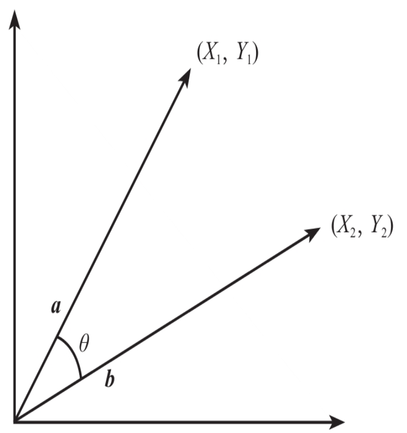

余弦相似度的取值范围为 $0\sim 1$, 夹角越小，余弦值越接近1，则两个向量越靠近，说明它们越相似

很容易知道, 两个向量 **$\pmb{a},\pmb{b}$** 的余弦相似度为:

$$ \cos <\pmb{a}, \pmb{b}> = \frac{\pmb{a}\cdot \pmb{b}}{|\pmb{a}| |\pmb{b}|} $$

容易理解, 借助余弦相似度能解决新闻标题的长度导致的分类不准确问题, 通过下图可以更好地理解欧式距离和余弦相似度的区别

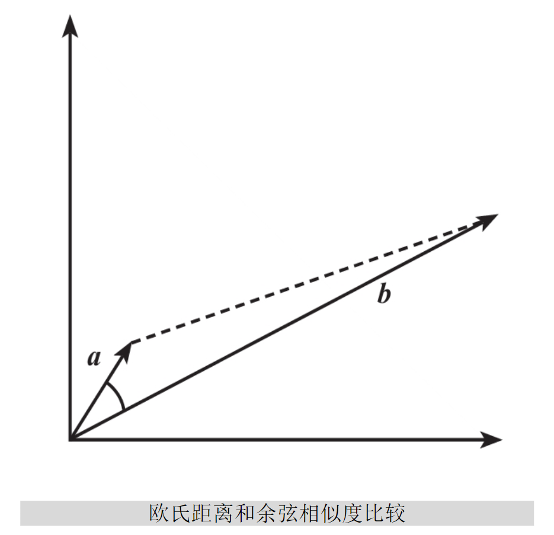

- 虚线为欧式距离
- 夹角的余弦值为余弦相似度
- a和b从余弦相似度上来看, 相似性远超欧式距离

#### 3. 余弦相似度的Python代码实现

```python
# 计算余弦相似度
from sklearn.metrics.pairwise import cosine_similarity
cosine_similarities  = cosine_similarity(df_test)
cosine_similarities
```

```
array([[1.       , 0.8660254, 0.8660254],
       [0.8660254, 1.       , 1.       ],
       [0.8660254, 1.       , 1.       ]])
```

第 $i$ 行第 $i$ 列的数字表示第 $i$ 个数据和第 $j$ 个数据的余弦相似度

#### 4. 利用余弦相似度进行模型优化

```python
from sklearn.metrics.pairwise import cosine_similarity
cosine_similarities  = cosine_similarity(df)

rounded_similarities = np.around(cosine_similarities, decimals=3)
print(rounded_similarities[1:10, 1:10])
```

```
[[1.    0.141 0.135 0.149 0.135 0.129 0.    0.    0.258]
 [0.141 1.    0.572 0.211 0.191 0.183 0.091 0.191 0.274]
 [0.135 0.572 1.    0.201 0.182 0.174 0.087 0.182 0.261]
 [0.149 0.211 0.201 1.    0.402 0.577 0.096 0.101 0.289]
 [0.135 0.191 0.182 0.402 1.    0.522 0.087 0.091 0.261]
 [0.129 0.183 0.174 0.577 0.522 1.    0.083 0.087 0.25 ]
 [0.    0.091 0.087 0.096 0.087 0.083 1.    0.696 0.083]
 [0.    0.191 0.182 0.101 0.091 0.087 0.696 1.    0.087]
 [0.258 0.274 0.261 0.289 0.261 0.25  0.083 0.087 1.   ]]
```

接下来用KMeans算法对余弦相似度的计算结果进行聚类分群, 此时每条新闻标题的特征变量就是和其他新闻标题的余弦相似度

```python
from sklearn.cluster import KMeans
kms = KMeans(n_clusters=10, random_state=123)
k_data = kms.fit_predict(cosine_similarities)
```

```python
print(k_data[0:20])
```

```
[2 4 4 4 4 4 4 2 2 4 4 4 4 4 4 4 4 4 4 4]
```

```python
# 把之前的分词结果转为数组
print(words[0:3])
words_ary = np.array(words)
print(words_ary[0:3])
```

```
['信托公司 2019 年 上半年 经营 业绩 概览', '首单 信托 型 企业 ABS 获批', '华能 贵 诚信 托孙磊 : 金融 科技 助力 打造 开放 信托 生态']
['信托公司 2019 年 上半年 经营 业绩 概览' '首单 信托 型 企业 ABS 获批'
 '华能 贵 诚信 托孙磊 : 金融 科技 助力 打造 开放 信托 生态']
```

```python
# 查看分类结果
import numpy as np
words_ary = np.array(words)
print(words_ary[k_data == 3][0:5])  # 可以把数字3改成其他数字看看效果
```

```
['装病 骗 政府 645 万 , 科技 远 不是 你 想 的 那样' '昔日 网游 第一股 迅游 科技 实控 人 被动 减持 , 商誉 压顶'
 'ChinaJoy   2019 丨 ITheat 热点 科技 展台 人气 火爆   这些 精彩 看点 不 容错过'
 '兴证 王涵 : 第四次 科技 革命 是 机遇 还是 挑战 ?' '《 科技 志愿 服务 管理 办法 》 开始 实行 !']
```

### 补充知识点: 大数据分词--jieba库的使用

这节详细介绍jieba库的安装和使用方法，包括如何对长文本进行中文分词及词频统 计

中文分词（Chinese Word Segmentation）是指将一个中文序列切分成一个个单独的词

在英文的行文中，单词之间是以空格作为分界符的，而中文的词语则没有一个形式上的分界符，因此在分词这一层面，中文比英文要复杂得多

#### 1. jieba库的安装与基本使用方法

在cmd中执行 `pip install jieba` 命令, 或再 Jupyter Notebook 中运行 `!pip install jieba` 代码即可安装jieba库

```python
# 之前的演示

import jieba
word = jieba.cut('我爱北京天安门') # cut()函数分词得到的word不是一个列表, 而是一个迭代器generator(), 其实和列表很相似, 可以理解成一个 "隐身的列表", 不过其元素要通过for循环来访问, 所以后两行代码不能写成print(word)
for i in word:
    print(i)
```

```
我
爱
北京
天安门
```

中文分词的核心操作就是jieba库的cut()函数的使用

上面演示的案例较为简单，下面对一个较长的文本内容进行中文分词及词频统计

#### 2. 读取文本内容并进行分词

下面的文件是2017年的信托行业年度报告, 约20万字, 业务分析人员关心的是报告中哪些内容更重要，一个简单的实现手段就是看哪些词出现的频率最高，那么其对应内容的重要程度可能就越高

要达到这一目的，需要进行中文大数据分词和词频统计

对该txt文件中的文本内容进行分词的代码如下

```python
import jieba
report = open('信托行业年度报告.txt', 'r').read()
words = jieba.cut(report)
```

```python
for index, word in enumerate(words): # enumerate(words) 会返回一个包含索引和元素的元组，索引从 0 开始
    if index >= 10:
        break
    print(word)
```

```
2017
年
信托业
面临
着
较为
复杂
的
外部环境
。
```

#### 3. 按指定长度提取分词后的词

```python
words = jieba.cut(report)  # 这里得重新jieba.cut()一下，因为之前的words用过一次就被清空了
report_words = []
for word in words:  # 将大于4个字的词语放入列表
    if len(word) >= 4:
        report_words.append(word)
print(report_words[0:20])
```

```
['2017', '外部环境', '结构调整', '新兴产业', '另一方面', '金融监管', '信托公司', '管理工作', '管理体系', '2017', '全面落实', '结构调整', '初见成效', '金融监管', '小康社会', '深远影响', '2017', '多管齐下', '长效机制', '长效机制']
```

#### 4. 统计高频词汇

```python
from collections import Counter
result = Counter(report_words)
print(result[0:20])
```

```
0
```

```python
result = Counter(report_words).most_common(50)  # 取最多的50组
print(result[0:20])
```

```
[('信托公司', 1391), ('2017', 577), ('2016', 184), ('金融机构', 148), ('投资信托', 108), ('基础产业', 91), ('2018', 87), ('风险管理', 82), ('工商企业', 77), ('QDII', 70), ('金融服务', 69), ('信息系统', 63), ('2015', 59), ('基础设施', 56), ('金融公司', 47), ('另一方面', 45), ('信托投资公司', 45), ('中国人民银行', 44), ('REITs', 39), ('金融业务', 38)]
```

### 补充知识点: 新闻爬取--百度新闻爬虫

百度新闻爬虫的相关知识点在作者的上一本书[《Python金融大数据挖掘与分析全流程详解》](https://item.jd.com/12568751.html?dist=jd)

第三章“金融数据挖掘案例实战1”中有详细的讲解，这里结合了本书第二章pandas库的相关知识点将数据进行整合，并导出成Excel文件方便使用

因为核心知识点在上一本书已经描述的较为详细，所以这里就不在赘述，通过如下代码可以爬取百度新闻多页多个关键词

```python
import requests
import re
headers = {'User-Agent': 'Mozilla/5.0 (Windows NT 10.0; Win64; x64) AppleWebKit/537.36 (KHTML, like Gecko) Chrome/69.0.3497.100 Safari/537.36'}

def baidu(keyword, page):  # 定义函数，方便之后批量调用
    num = (page - 1) * 10
    url = 'https://www.baidu.com/s?tn=news&rtt=4&bsst=1&cl=2&wd=' + keyword + '&pn=' + str(num)
    res = requests.get(url, headers=headers).text  # 通过requests库爬虫

    # 正则提取信息
    p_href = '<h3 class="c-title">.*?<a href="(.*?)"'
    p_title = '<h3 class="c-title">.*?>(.*?)</a>'
    p_info = '<p class="c-author">(.*?)</p>'
    href = re.findall(p_href, res, re.S)
    title = re.findall(p_title, res, re.S)
    info = re.findall(p_info, res, re.S)

    # 数据清洗
    source = []
    date = []
    for i in range(len(title)):
        title[i] = title[i].strip()
        title[i] = re.sub('<.*?>', '', title[i])
        info[i] = re.sub('<.*?>', '', info[i])
        source.append(info[i].split('&nbsp;&nbsp;')[0])
        date.append(info[i].split('&nbsp;&nbsp;')[1])
        source[i] = source[i].strip()
        date[i] = date[i].strip()

    # 通过2.2.1节字典生成二维DataFrame表格
    result = pd.DataFrame({'关键词': keyword, '标题': title, '网址': href, '来源': source, '日期': date})
    return result

# 通过pandas库将数据进行整合并导出为Excel
import pandas as pd
df = pd.DataFrame()

keywords = ['华能信托', '人工智能']
for keyword in keywords:
    for i in range(4):  # 循环10遍，获取10页的信息
        result = baidu(keyword, i+1)
        df = pd.concat([df, result], ignore_index=True)
        print(keyword + '第' + str(i+1) + '页爬取成功')

df.to_excel('新闻_new.xlsx')  # 在代码所在文件夹生成EXCEL文件
```

```
华能信托第1页爬取成功
华能信托第2页爬取成功
华能信托第3页爬取成功
华能信托第4页爬取成功
人工智能第1页爬取成功
人工智能第2页爬取成功
人工智能第3页爬取成功
人工智能第4页爬取成功
```